# Exploratory Data Analysis Report

2019-03-15

## Exploratory Data analysis (EDA)

Analyzing the data sets to summarize their main characteristics of variables, often with visual graphs, without using a statistical model.

### 1. Overview of the data

Understanding the dimensions of the dataset, variable names, overall missing summary and data types of each variables

```r
# Overiview of the data
ExpData(data=data,type=1)
# Structure of the data
ExpData(data=data,type=2)
```

**Overview of the data**

| Descriptions | Obs |
| --- | --- |
| Sample size (Nrow) | 1000 |
| No. of Variables (Ncol) | 9 |
| No. of Numeric Variables | 2 |
| No. of Factor Variables | 3 |
| No. of Text Variables | 2 |
| No. of Logical Variables | 2 |
| No. of Date Variables | 0 |
| No. of Zero variance Variables (Uniform) | 0 |
| %. of Variables having complete cases | 55.56% (5) |
| %. of Variables having <50% missing cases | 44.44% (4) |

[output cut: 2 more lines]

**Structure of the data**

| S.no | Variable Name | Variable Type | % of Missing | No. of Unique values |
| --- | --- | --- | --- | --- |
| 1 | ID* | character | 0 | 1000 |
| 2 | Race* | factor | 0.11 | 8 |
| 3 | Age* | character | 0.12 | 17 |
| 4 | Sex* | factor | 0 | 2 |
| 5 | Height_cm_ | numeric | 0 | 365 |
| 6 | IQ | numeric | 0.1 | 58 |
| 7 | Smokes | logical | 0 | 2 |
| 8 | Income* | factor | 0.1 | 901 |
| 9 | Died | logical | 0 | 2 |

**Target variable**

Summary of categorical dependent variable

```
##    Died Frequency Descriptions
## 1 FALSE       465         Died
## 2  TRUE       535         Died
```

### 2. Summary of numerical variables

Summary of all numerical variables

Summary statistics when dependent variable is categorical **Died**. Summary statistics will be splitted into category level

```r
ExpNumStat(data,by="GA",gp=Target,Qnt=seq(0,1,0.1),MesofShape=2,Outlier=TRUE,round=2)
```

| Vname | Group | TN | nNeg | nZero | nPos | NegInf | PosInf | NA_Value | Per_of_Missing | sum | min | max | mean | median | SD | CV | IQR | Skweness | Kurtosis | 0% | 10% | 20% | 30% | 40% | 50% | 60% | 70% | 80% | 90% | … |
| --- | --- | --- | --- | --- | --- | --- | --- | --- | --- | --- | --- | --- | --- | --- | --- | --- | --- | --- | --- | --- | --- | --- | --- | --- | --- | --- | --- | --- | --- | --- |
| Height_cm_ | Died:All | 1000 | 0 | 0 | 1000 | 0 | 0 | 0 | 0.00 | 175087.0 | 146.3 | 207.2 | 175.09 | 175.3 | 9.83 | 0.06 | 13.83 | -0.09 | -0.30 | 146.3 | 161.77 | 166.40 | 169.90 | 172.86 | 175.3 | 177.8 | 180.43 | 183.60 | 187.71 | … |
| Height_cm_ | Died:FALSE | 465 | 0 | 0 | 465 | 0 | 0 | 0 | 0.00 | 81004.9 | 150.8 | 201.1 | 174.20 | 174.5 | 9.32 | 0.05 | 13.10 | 0.04 | -0.40 | 150.8 | 162.18 | 165.78 | 169.12 | 172.06 | 174.5 | 176.8 | 179.16 | 182.42 | 185.88 | … |
| Height_cm_ | Died:TRUE | 535 | 0 | 0 | 535 | 0 | 0 | 0 | 0.00 | 94082.1 | 146.3 | 207.2 | 175.85 | 176.3 | 10.21 | 0.06 | 14.15 | -0.21 | -0.21 | 146.3 | 161.30 | 167.30 | 171.00 | 173.66 | 176.3 | 178.9 | 181.28 | 184.60 | 188.88 | … |
| IQ | Died:All | 1000 | 0 | 0 | 898 | 0 | 0 | 102 | 10.20 | 90008.0 | 68.0 | 137.0 | 100.23 | 100.0 | 10.03 | 0.10 | 14.00 | 0.08 | -0.04 | 68.0 | 87.00 | 92.00 | 95.00 | 98.00 | 100.0 | 102.0 | 105.00 | 109.00 | 113.00 | … |
| IQ | Died:FALSE | 465 | 0 | 0 | 422 | 0 | 0 | 43 | 9.25 | 42505.0 | 68.0 | 129.0 | 100.72 | 101.0 | 10.34 | 0.10 | 14.00 | -0.06 | -0.07 | 68.0 | 87.00 | 92.00 | 96.00 | 98.00 | 101.0 | 103.0 | 106.00 | 109.80 | 114.90 | … |
| IQ | Died:TRUE | 535 | 0 | 0 | 476 | 0 | 0 | 59 | 11.03 | 47503.0 | 75.0 | 137.0 | 99.80 | 99.0 | 9.74 | 0.10 | 13.00 | 0.20 | 0.03 | 75.0 | 87.00 | 92.00 | 95.00 | 97.00 | 99.0 | 102.0 | 104.00 | 108.00 | 113.00 | … |

### 3. Distributions of Numerical variables

- Box plots for all numerical variables vs categorical dependent variable - Bivariate comparision only with categories
- Quantile-quantile plot(Univariate)
- Density plot (Univariate)
- Box plot (univariate and Bivariate)

#### Quantile-quantile plot for Numerical variables - Univariate

Quantile-quantile plot for all Numerical variables

```r
ExpOutQQ(data,nlim=4,fname=NULL,Page=c(2,2),sample=sn)
```

```
## $`0`
```

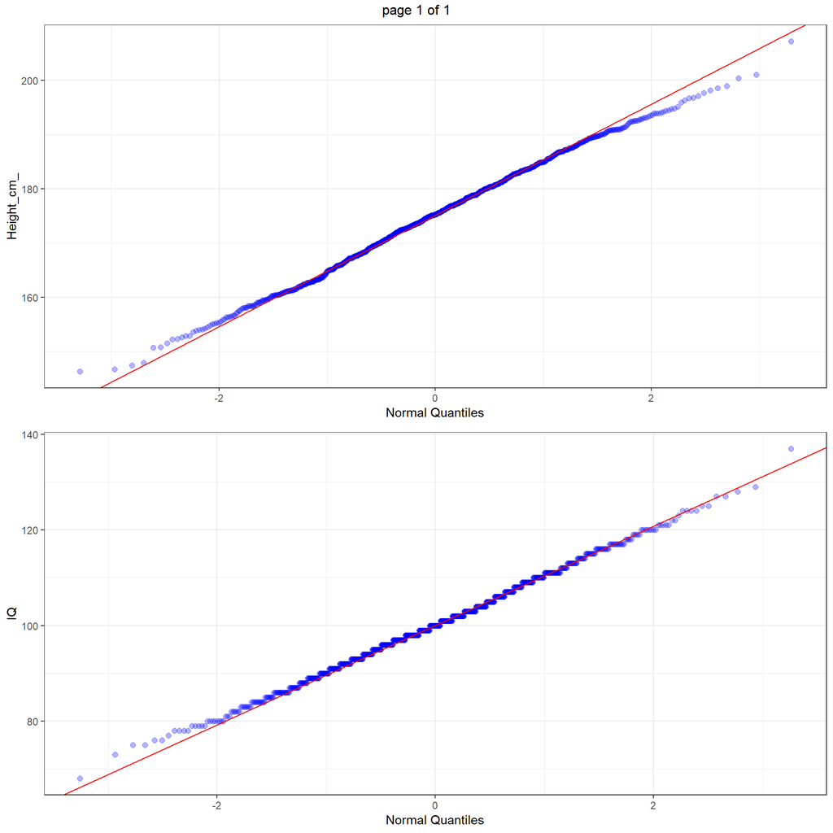

#### Density plots for Numerical variables - Univariate

Density plot for all Numerical variables

```
## $`0`
```

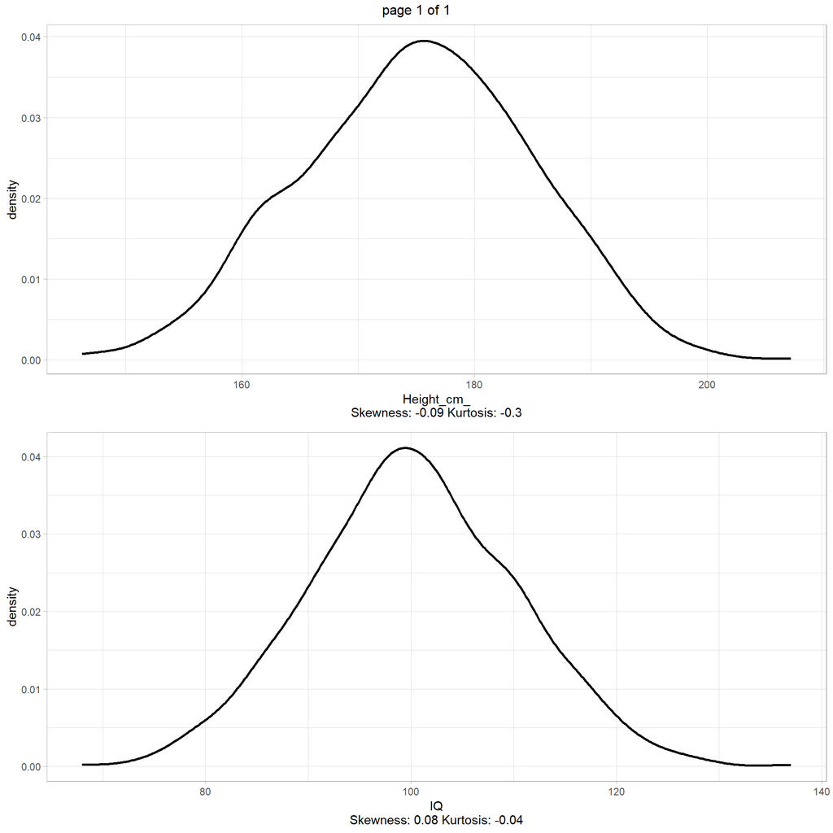

```r
ExpNumViz(data,gp=NULL,type=1,nlim=NULL,fname=NULL,col=NULL,Page=c(2,2),sample=sn)
```

#### Box plots for all numeric features vs categorical dependent variable - Bivariate comparision only with categories

Boxplot for all the numeric attributes by each category of **Died**

```
## $`0`
```

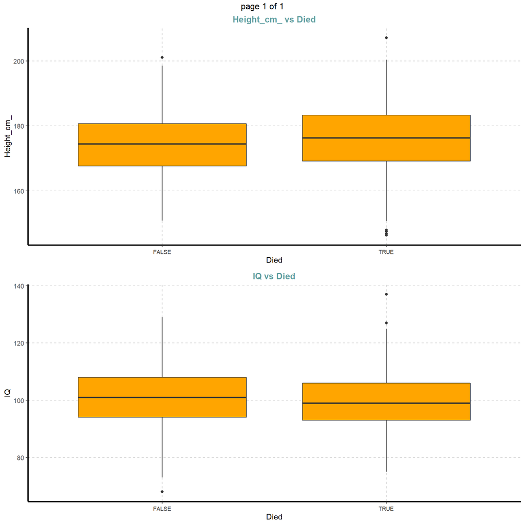

```r
ExpNumViz(data,gp=Target,type=2,nlim=NULL,fname=NULL,col=NULL,Page=c(2,2),sample=sn)
```

### 4. Summary of categorical variables

Summary of categorical variable

**Cross tabulation with target variable**

- Custom tables between all categorical independent variables and traget variable **Died**

```r
ExpCTable(data,Target=Target,margin=1,clim=10,nlim=NULL,round=2,bin=NULL,per=F)
```

| VARIABLE | CATEGORY | Died:FALSE | Died:TRUE | TOTAL |
| --- | --- | --- | --- | --- |
| Race | Asian | 14 | 14 | 28 |
| Race | Bi-Racial | 5 | 13 | 18 |
| Race | Black | 56 | 58 | 114 |
| Race | Hispanic | 75 | 71 | 146 |
| Race | NA | 52 | 55 | 107 |
| Race | Native | 2 | 5 | 7 |
| Race | Other | 0 | 1 | 1 |
| Race | White | 261 | 318 | 579 |
| Race | TOTAL | 465 | 535 | 1000 |
| Sex | Female | 204 | 275 | 479 |

[output cut: 2 more lines]

**Information Value**

```r
ExpCatStat(data,Target=Target,Label=label,result = "IV",clim=10,nlim=5,Pclass=Rc)
```

| Variable | Target | Class | Out_1 | Out_0 | TOTAL | Per_1 | Per_0 | Odds | WOE | IV | Ref_1 | Ref_0 |
| --- | --- | --- | --- | --- | --- | --- | --- | --- | --- | --- | --- | --- |
| Race | Died | Asian | 14 | 14 | 28 | 0.030 | 0.026 | 1.154 | 0.143 | 0.001 | FALSE | TRUE |
| Race | Died | Bi-Racial | 5 | 13 | 18 | 0.011 | 0.024 | 0.458 | -0.781 | 0.010 | FALSE | TRUE |
| Race | Died | Black | 56 | 58 | 114 | 0.120 | 0.108 | 1.111 | 0.105 | 0.001 | FALSE | TRUE |
| Race | Died | Hispanic | 75 | 71 | 146 | 0.161 | 0.133 | 1.211 | 0.191 | 0.005 | FALSE | TRUE |
| Race | Died | NA | 52 | 55 | 107 | 0.112 | 0.103 | 1.087 | 0.083 | 0.001 | FALSE | TRUE |
| Race | Died | Native | 2 | 5 | 7 | 0.004 | 0.009 | 0.444 | -0.812 | 0.004 | FALSE | TRUE |
| Race | Died | Other | 0 | 1 | 1 | 0.000 | 0.002 | 0.000 | 0.000 | 0.000 | FALSE | TRUE |
| Race | Died | White | 261 | 318 | 579 | 0.561 | 0.594 | 0.944 | -0.058 | 0.002 | FALSE | TRUE |
| Sex | Died | Female | 204 | 275 | 479 | 0.439 | 0.514 | 0.854 | -0.158 | 0.012 | FALSE | TRUE |
| Sex | Died | Male | 261 | 260 | 521 | 0.561 | 0.486 | 1.154 | 0.143 | 0.011 | FALSE | TRUE |

**Statistical test**

```r
ExpCatStat(data,Target=Target,Label=label,result = "Stat",clim=10,nlim=5,Pclass=Rc)
```

| Variable | Target | Unique | Chi-squared | p-value | df | IV Value | Cramers V | Degree of Association | Predictive Power |
| --- | --- | --- | --- | --- | --- | --- | --- | --- | --- |
| Race | Died | 8 | NaN | NaN | 7 | 0.024 | NaN | Very Weak | Not Predictive |
| Sex | Died | 2 | 5.356 | 0.021 | 1 | 0.023 | 0.07 | Very Weak | Not Predictive |

### 5. Distributions of categorical variables

Graphical representation of all categorical variables

**Bar plots for all categorical variables**

- Bar plot with vertical or horizontal bars for all categorical variables

```
## $`0`
```

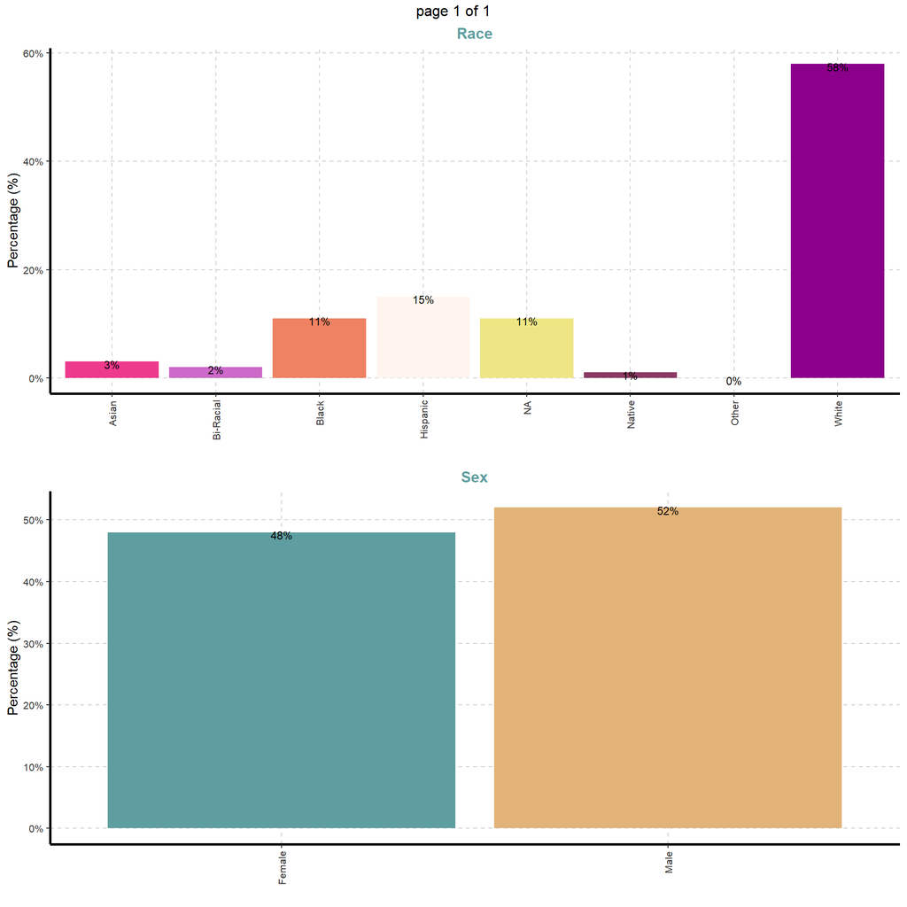

```r
ExpCatViz(data,gp=NULL,fname=NULL,clim=10,margin=2,Page = c(2,2),sample=sc)
```

```
## $`0`
```

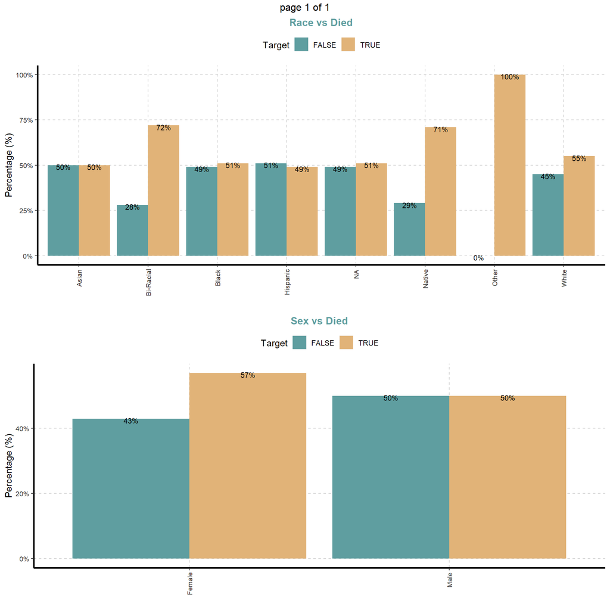

```r
ExpCatViz(data,gp=Target,fname=NULL,clim=10,margin=2,Page = c(2,2),sample=sc)
```